# timeSeriseAll

tedding

June 15, 2016

Environment settings

```r
setwd('F:/百度云同步盘/2016H1/25.时间序列整理/')

#dir <- iconv(rstudioapi::getActiveDocumentContext()$path, 'utf8','gbk') # win
#dir <- rstudioapi::getActiveDocumentContext()$path # mac
#dir <- substr(dir, 1,
#              gregexpr( '/', dir)[[1]][ length(gregexpr( '/', dir)[[1]])] )
# setwd(dir)

data <- read.csv('tdata1.csv', header = T )
data[,1] = as.Date( data[,1])
head(data)
```

```
##         date   new     log income
## 1 2015-03-01 71383 2666169  745.0
## 2 2015-03-02 54572 2192393  580.3
## 3 2015-03-03 52306 2147821  539.1
## 4 2015-03-04 52093 2162540  552.1
## 5 2015-03-05 64262 2392343  624.5
## 6 2015-03-06 68040 2522522  742.6
```

# data fromation

ts is the basic format of time series data in R, zoo&xts are enhanced ones.

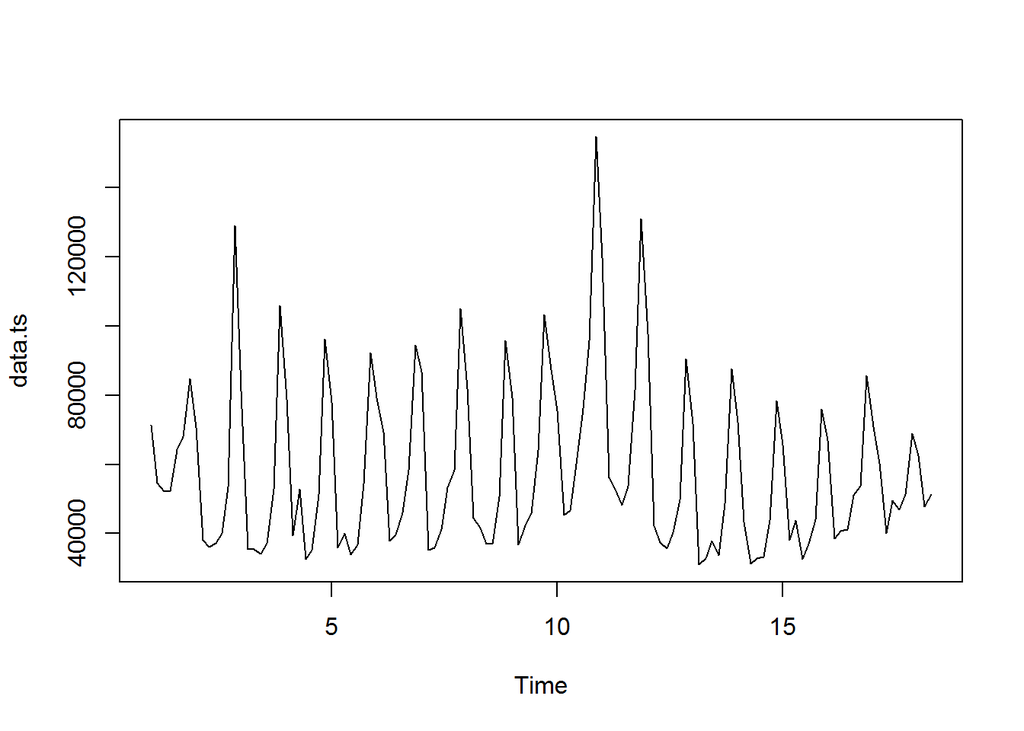

```r
data.ts = ts( data$new , frequency = 7 )
plot(data.ts)
```

xts way

```r
library(xts)
```

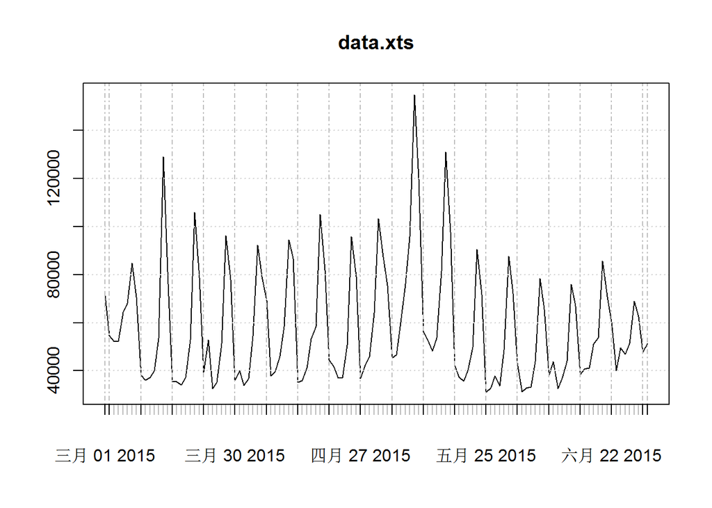

```r
data.xts = xts( data$new,  data$date) # , frequency = 7
plot(data.xts)
```

# view of the data

extract some time

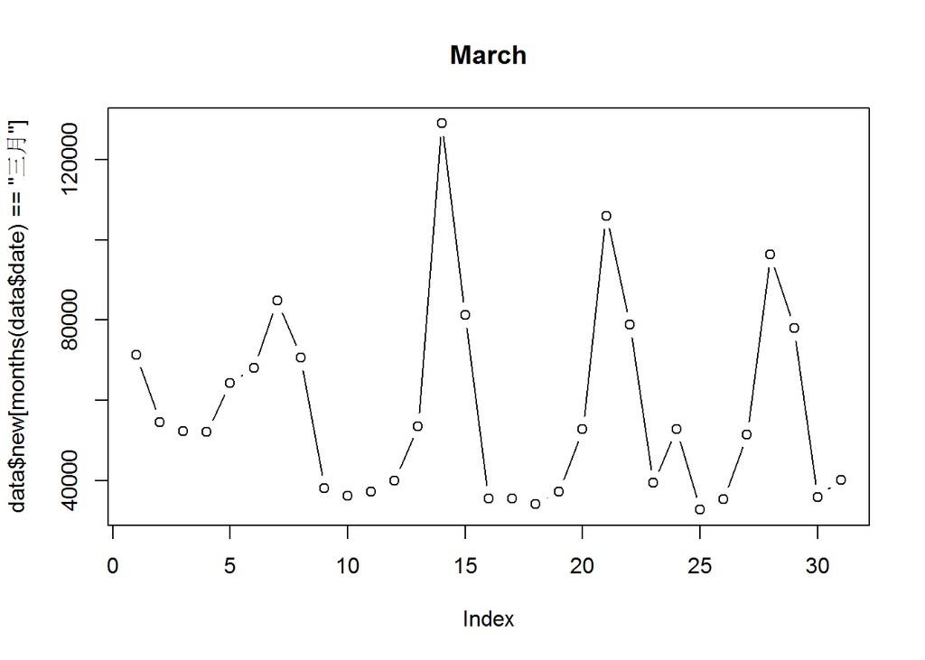

```r
plot( data$new[ months(data$date) == '三月' ], type = 'b', main ='March')
```

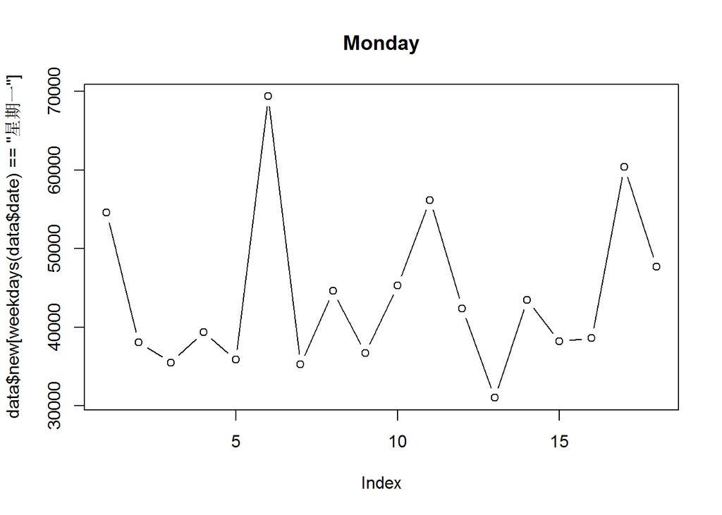

```r
plot( data$new[ weekdays(data$date) == '星期一' ], type = 'b', main ='Monday')
```

considering the week days

```r
library(forecast)
```

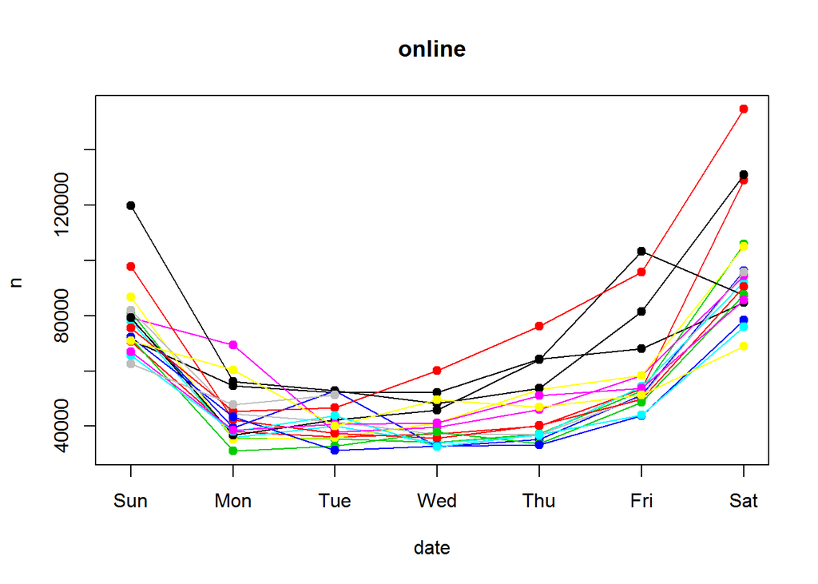

```r
seasonplot( data[,2] , ylab="n ", xlab="date", main="online",
           s = 7, year.labels=F, year.labels.left=F, col=1:10, pch=19)
```

```r
# here s means the same as frequency of ts
# monthplot( data[,2] ,ylab="xx",xlab="Month",main="Seasonal deviation plot")
```

# extract and transform

## Time series decomposition

A trend exists when there is a long-term increase or decrease in the data. A seasonal pattern occurs when a time series is affected by seasonal factors such as the time of the year or the day of the week. A cycle occurs when the data exhibit rises and falls that are not of a fixed period.

classic decomposition

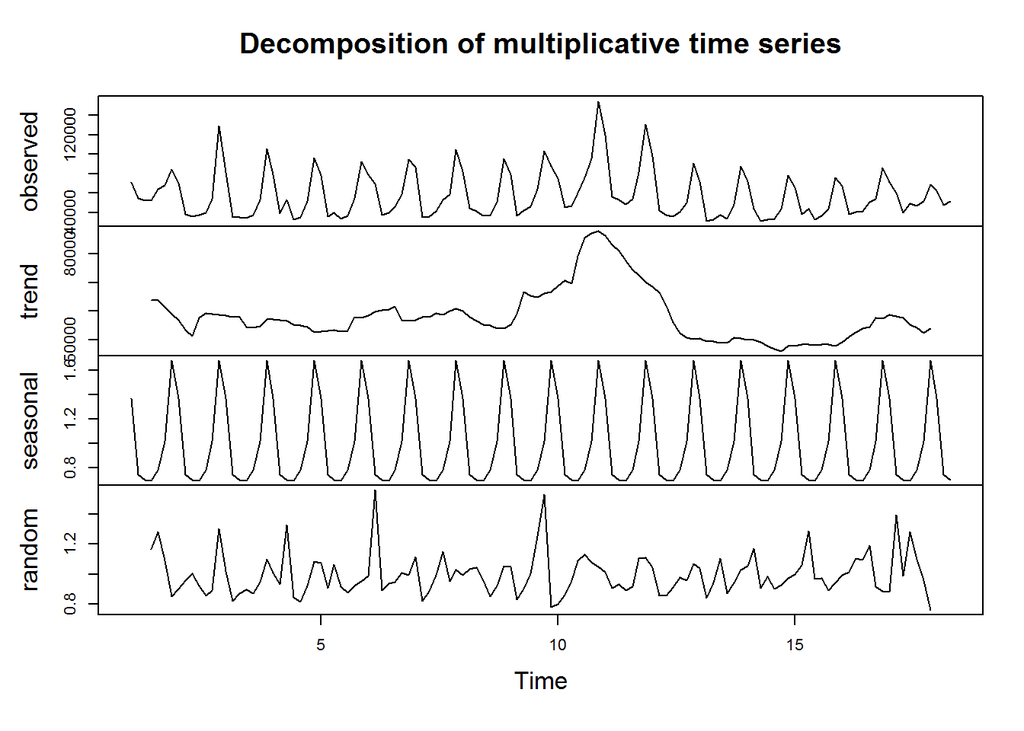

```r
plot( decompose( data.ts, type="multiplicative") )
```

## week effect

```r
summary( aov( data$new ~ weekdays(data$date) ))
```

```
##                      Df    Sum Sq   Mean Sq F value Pr(>F)
## weekdays(data$date)   6 5.019e+10 8.365e+09   44.48 <2e-16 ***
## Residuals           115 2.163e+10 1.881e+08
## ---
## Signif. codes:  0 '***' 0.001 '**' 0.01 '*' 0.05 '.' 0.1 ' ' 1
```

```r
effect.week = aggregate( data$new, by = list(weekday= weekdays(data$date)), mean)
effect.week$x = effect.week$x/ min(effect.week$x)
effect.week
```

```
##   weekday        x
## 1  星期二 1.025819
## 2  星期六 2.403244
## 3  星期日 1.924839
## 4  星期三 1.000000
## 5  星期四 1.135690
## 6  星期五 1.472423
## 7  星期一 1.081804
```

## outlier detection - tsoutliers

- IO innovational outlier
- AO additive outlier
- LS level shift
- TC temporary change
- SLS seasonal level shift

```r
# install.packages(‘tsoutliers’)

library("tsoutliers")
data(Nile)
resNile1 <- tso(y = Nile, types = c("AO", "LS", "TC"),
                tsmethod = "stsm", args.tsmodel = list(model = "local-level"))
```

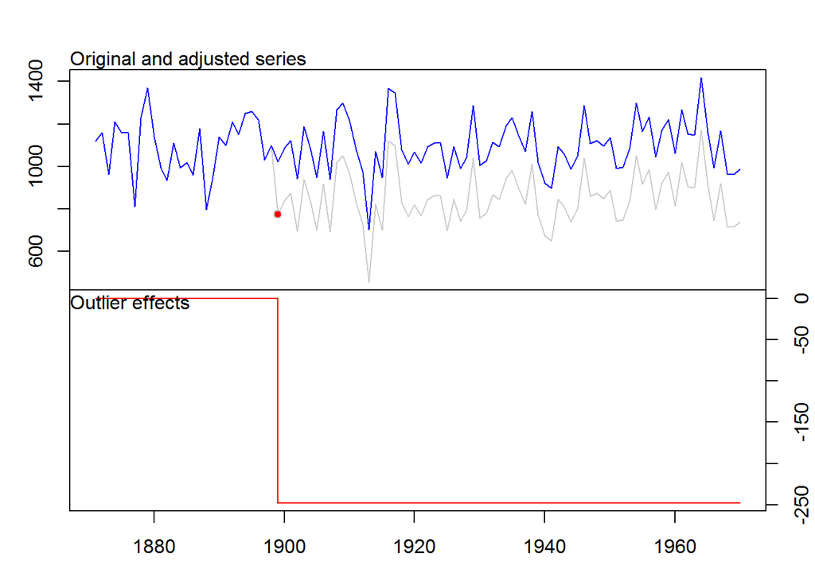

```r
plot(resNile1)
```

```r
resNile2 <- tso(y = Nile, types = c("AO", "LS", "TC"),
                remove.method = "bottom-up", tsmethod = "auto.arima",
                cval = 1.5 ,  # between 3-4, less more points
                args.tsmethod = list(allowdrift = FALSE, ic = "bic"))
resNile2
```

```
## Series: Nile
## ARIMA(0,0,0) with non-zero mean
##
## Coefficients:
##       intercept       TC4        AO7       AO9       AO18      TC22
##       1045.5207  190.8563  -297.9844  292.4021  -247.8151  159.1622
## s.e.    21.2714   67.8134    83.0059   81.9998    82.5850   69.7592
##           TC24       LS26      TC38       AO43      TC46       TC49
##       272.5193  -227.3310  211.1960  -398.0852  280.0666  -161.2628
## s.e.   68.2766    28.7789   66.4549    82.0183   65.9121    62.6700
##          LS51       AO55      AO59      AO68       TC70      AO76
##       44.9318  -157.9477  178.6009  146.9479  -207.5253  201.2976
## s.e.  25.0368    81.1591   81.0390   81.0760    61.7341   80.9325
##           AO91      AO94      LS96
##       156.9944  306.9182  -95.7108
## s.e.   81.0761   81.0776   38.3664
##
## sigma^2 estimated as 8072:  log likelihood=-579.92
## AIC=1203.83   AICc=1216.98   BIC=1261.15
##
## Outliers:
##    type ind time coefhat  tstat
## 1    TC   4 1874  190.86  2.814
## 2    AO   7 1877 -297.98 -3.590
## 3    AO   9 1879  292.40  3.566
## 4    AO  18 1888 -247.82 -3.001
## 5    TC  22 1892  159.16  2.282
## 6    TC  24 1894  272.52  3.991
## 7    LS  26 1896 -227.33 -7.899
## 8    TC  38 1908  211.20  3.178
## 9    AO  43 1913 -398.09 -4.854
## 10   TC  46 1916  280.07  4.249
## 11   TC  49 1919 -161.26 -2.573
## 12   LS  51 1921   44.93  1.795
## 13   AO  55 1925 -157.95 -1.946
## 14   AO  59 1929  178.60  2.204
## 15   AO  68 1938  146.95  1.812
## 16   TC  70 1940 -207.53 -3.362
## 17   AO  76 1946  201.30  2.487
## 18   AO  91 1961  156.99  1.936
## 19   AO  94 1964  306.92  3.785
## 20   LS  96 1966  -95.71 -2.495
```

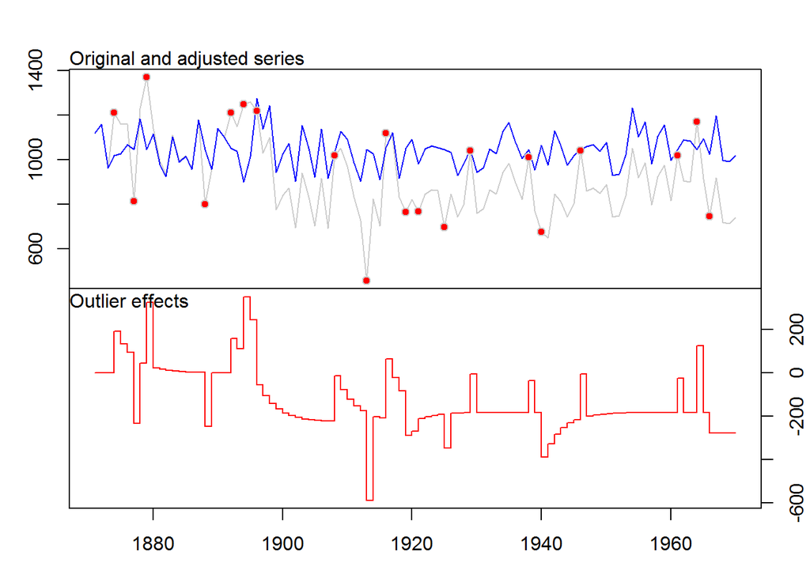

```r
plot(resNile2)
```

# simple way of forecast framework (too simple to use)

## means

forecasting methods and evaluation  
rwf: Returns forecasts and prediction intervals for a random walk with drift model applied to x.

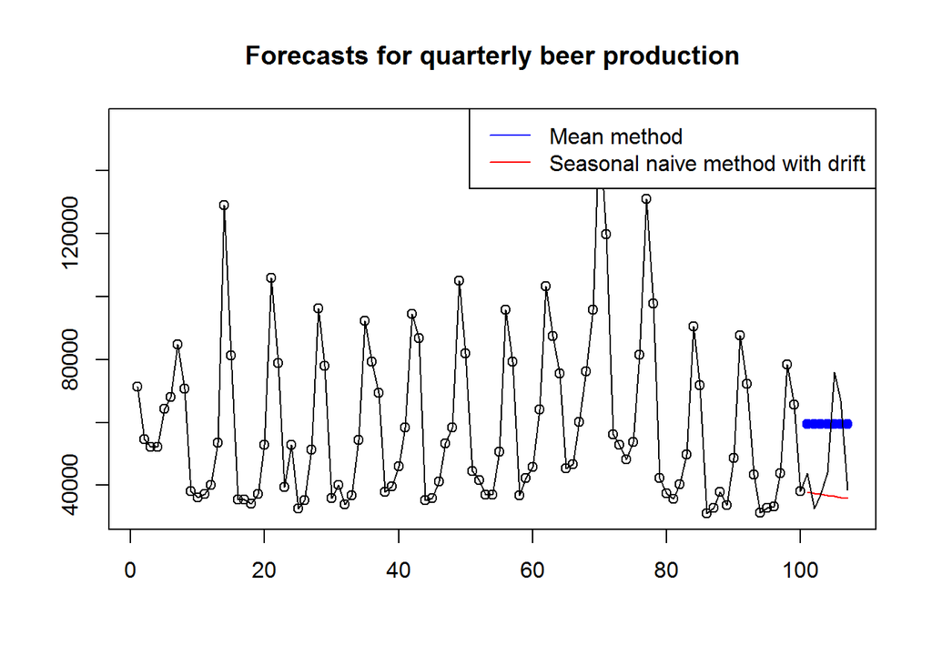

```r
f.meanf <- meanf(data.ts[1:100],h=7)
f.rwf <- rwf( data.ts[1:100], drift = T ,h=7)

plot( f.meanf, plot.conf=FALSE, main="Forecasts for quarterly beer production")
lines( f.rwf$mean,col=2)
lines( 1:107, data.ts[1:107] )
legend("topright", lty=1, col=c(4,2),
       legend=c("Mean method", "Seasonal naive method with drift"))
```

```r
accuracy( f.meanf, data.ts[101:107] )
```

```
##                         ME     RMSE      MAE       MPE     MAPE      MASE
## Training set  2.400515e-12 25865.25 21248.69 -16.89007 38.84926 1.0000000
## Test set     -1.108024e+04 18824.13 17908.02 -33.64294 42.99911 0.8427823
```

```r
accuracy( f.rwf, data.ts[101:107] )
```

```
##                         ME     RMSE      MAE       MPE     MAPE      MASE
## Training set -2.574461e-13 26154.62 19409.61 -8.132422 32.80620 1.0015368
## Test set      1.161644e+04 19385.20 13064.55 17.127669 21.55556 0.6741311
##                   ACF1
## Training set 0.1198494
## Test set            NA
```

```r
### Mean absolute error
### Root mean squared error
```

Moving averages cannot used for forecast

## STL decomposition

Seasonal and Trend decomposition using Loess seasonally adjusted data and re-seasonalizing using the last year of the seasonal component.

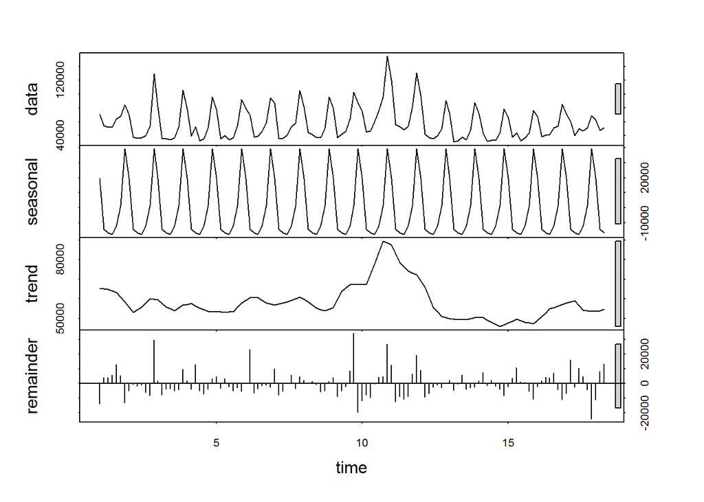

```r
stl <- stl( data.ts, s.window = 'periodic' )
plot( stl ) # difference between decompose ???
```

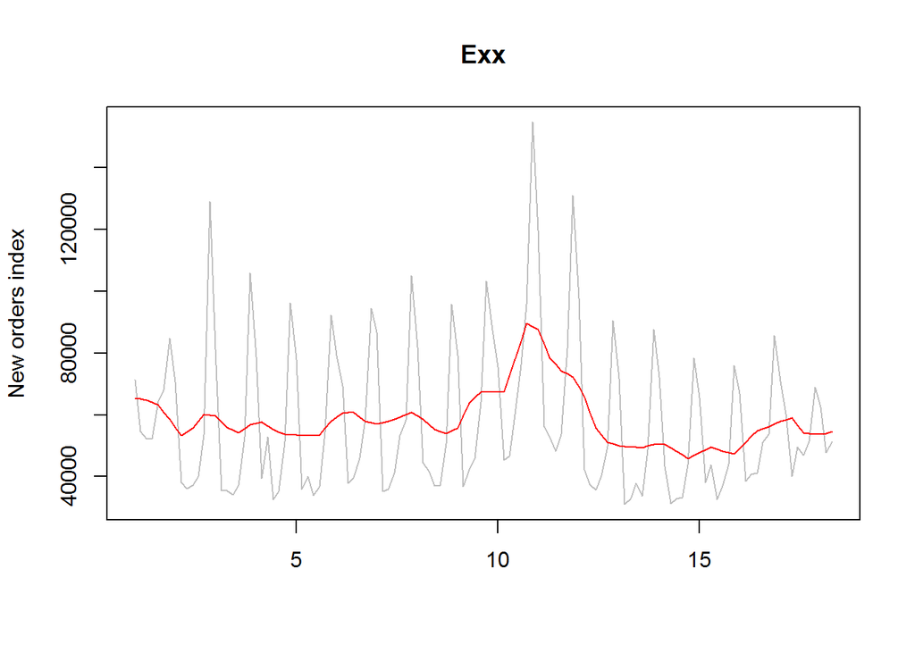

```r
plot( data.ts , col="gray", main="Exx", ylab="New orders index", xlab="")
lines( stl$time.series[,2],col="red",ylab="Trend")
```

The two main parameters to be chosen when using STL are the trend window (t.window) and seasonal window (s.window), These control how rapidly the trend and seasonal components can change. Small values allow more rapid change. Setting the seasonal window to be infinite is equivalent to forcing the seasonal component to be periodic (i.e., identical across years).

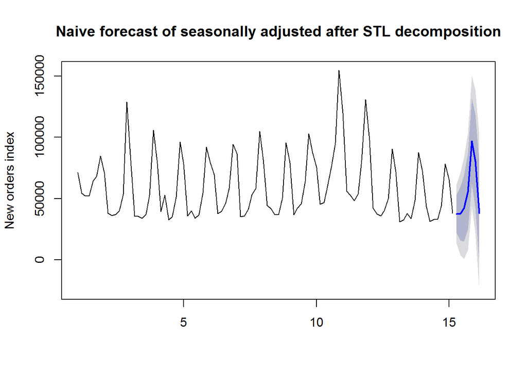

```r
model.stl <- stl( ts(data$new[1:100], frequency = 7) ,
               t.window=7, s.window="periodic", robust=TRUE)
f.stl <- forecast(model.stl, method="naive", h = 7)
plot( f.stl, ylab="New orders index",
     main = "Naive forecast of seasonally adjusted after STL decomposition")
```

```r
accuracy( f.stl, data.ts[101:107] )
```

```
##                       ME     RMSE      MAE        MPE     MAPE      MASE
## Training set    90.93827 12104.13 7755.973  -0.848014 13.17728 0.4002085
## Test set     -7058.15122 10970.20 9004.014 -12.569888 17.04674 0.4646075
##                    ACF1
## Training set -0.2121731
## Test set             NA
```

# Arima models

## Stationarity and differencing

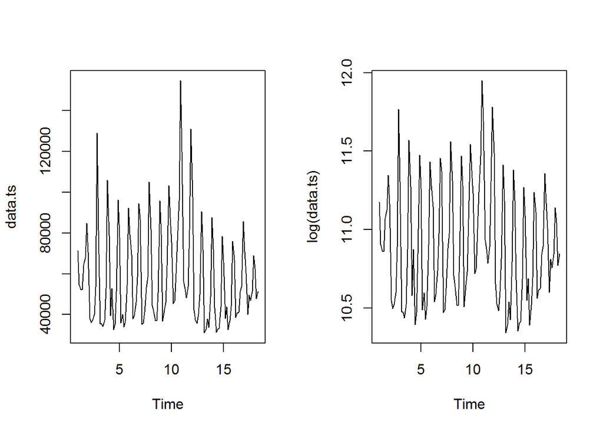

```r
par(mfrow =c(1,2))
plot( data.ts)
plot( log(data.ts))
```

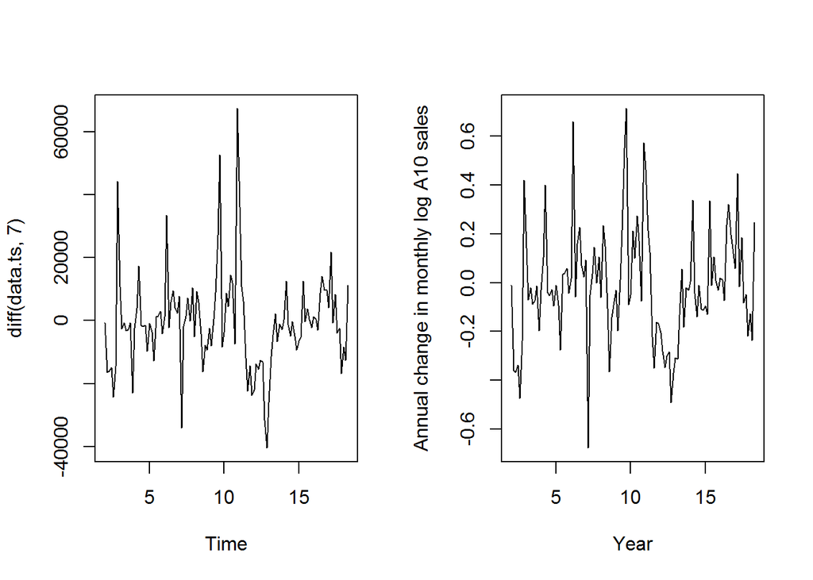

```r
plot( diff(data.ts, 7))
plot(diff(log(data.ts),7), xlab="Year",
  ylab="Annual change in monthly log A10 sales")
```

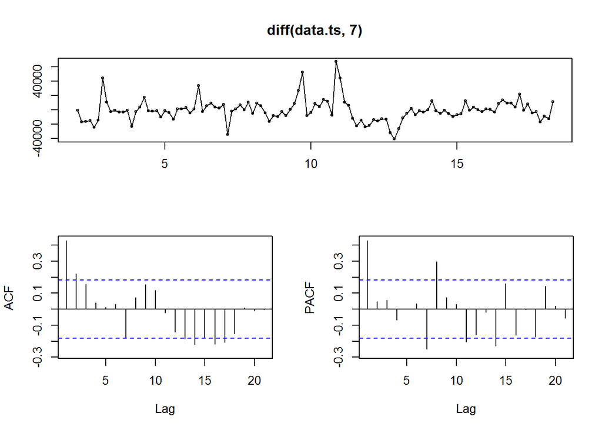

```r
par(mfrow=c(1,1))
tsdisplay(diff( data.ts ,7))
```

```r
library(tseries)
adf.test(data.ts, alternative = "stationary")
```

```
##
##  Augmented Dickey-Fuller Test
##
## data:  data.ts
## Dickey-Fuller = -5.967, Lag order = 4, p-value = 0.01
## alternative hypothesis: stationary
```

Large p-values are indicative of non-stationarity, and small p-values suggest stationarity. Using the usual 5% threshold, differencing is required if the p-value is greater than 0.05. Sometimes it is just not possible to find a model that passes all the tests.

## general arima

ARIMA(p,d,q) model

- p= order of the autoregressive part;
- d= degree of first differencing involved;
- q= order of the moving average part.

some simple arima models

- White noise ARIMA(0,0,0)
- Random walk ARIMA(0,1,0) with no constant
- Random walk with drift ARIMA(0,1,0) with a constant
- Autoregression ARIMA(p,0,0)
- Moving average ARIMA(0,0,q) ## modelling procedure 1.Plot the data. Identify any unusual observations.  
  2.If necessary, transform the data (using a Box-Cox transformation) to stabilize the variance.  
  3.If the data are non-stationary: take first differences of the data until the data are stationary.  
  4.Examine the ACF/PACF: Is an AR(pp) or MA(qq) model appropriate?  
  5.Try your chosen model(s), and use the AICc to search for a better model.  
  6.Check the residuals from your chosen model by plotting the ACF of the residuals, and doing a portmanteau test of the residuals. If they do not look like white noise, try a modified model.  
  7.Once the residuals look like white noise, calculate forecasts.

example from book :

```r
library(fpp) # for data source
```

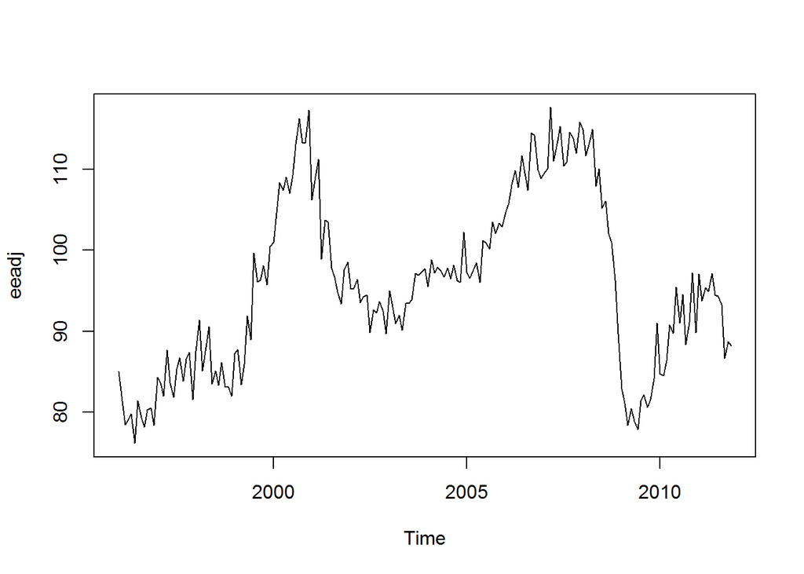

```r
eeadj <- seasadj(stl(elecequip, s.window="periodic"))
plot(eeadj)
```

1.The big drop in 2008/2009 due to the global economic environment. Otherwise there is nothing unusual about the time plot and there appears to be no need to do any data adjustments. 2.There is no evidence of changing variance, so we will not do a Box-Cox transformation. 3.The data are clearly non-stationary . Consequently, we will take a first difference of the data. These look stationary, and so we will not consider further differences.

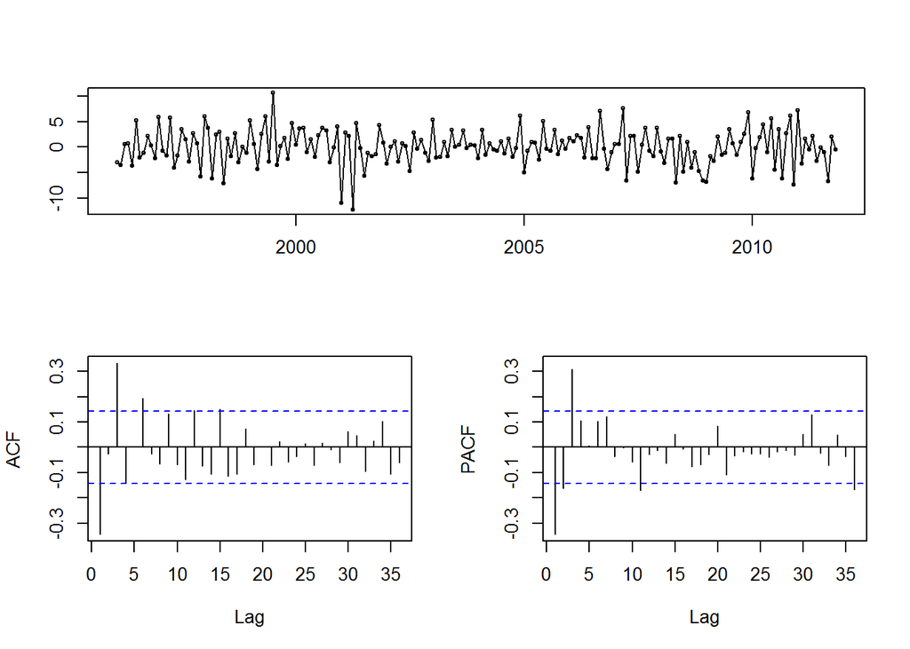

```r
tsdisplay(diff(eeadj),main="")
```

4.The PACF shown above suggests an AR(3) model. So an initial candidate model is an ARIMA(3,1,0). There are no other obvious candidate models. 5.We fit an ARIMA(3,1,0) model along with variations including ARIMA(4,1,0), ARIMA(2,1,0), ARIMA(3,1,1), etc. Of these, the ARIMA(3,1,1) has a slightly smaller AICc value.

```r
fit <- Arima(eeadj, order=c(3,1,0))
fit$aic
```

```
## [1] 979.3314
```

```r
fit <- Arima(eeadj, order=c(2,1,1))
fit$aic
```

```
## [1] 991.5201
```

```r
fit <- Arima(eeadj, order=c(3,1,1))
fit$aic
```

```
## [1] 978.1664
```

6. The ACF plot of the residuals from the ARIMA(3,1,1) model shows all correlations within the threshold limits indicating that the residuals are behaving like white noise.

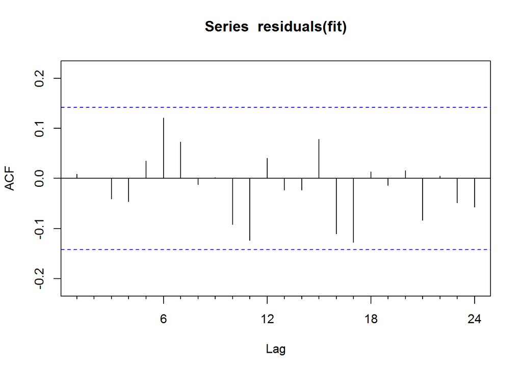

```r
Acf(residuals(fit))
```

```r
Box.test(residuals(fit), lag=24, fitdf=4, type="Ljung")
```

```
##
##  Box-Ljung test
##
## data:  residuals(fit)
## X-squared = 20.496, df = 20, p-value = 0.4273
```

7. Forecasts from the chosen model are shown in Figure 8.13.

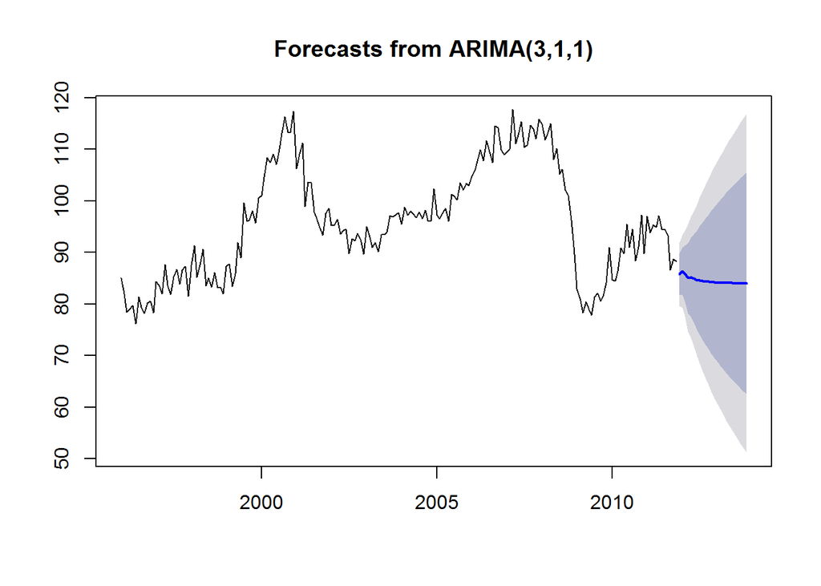

```r
plot(forecast(fit))
```

## Seasonal arima models

ARIMA(p,d,q)(P,D,Q)

Quarterly retail trade index in the Euro area (17 countries), 1996–2011, covering wholesale and retail trade, and repair of motor vehicles and motorcycles.

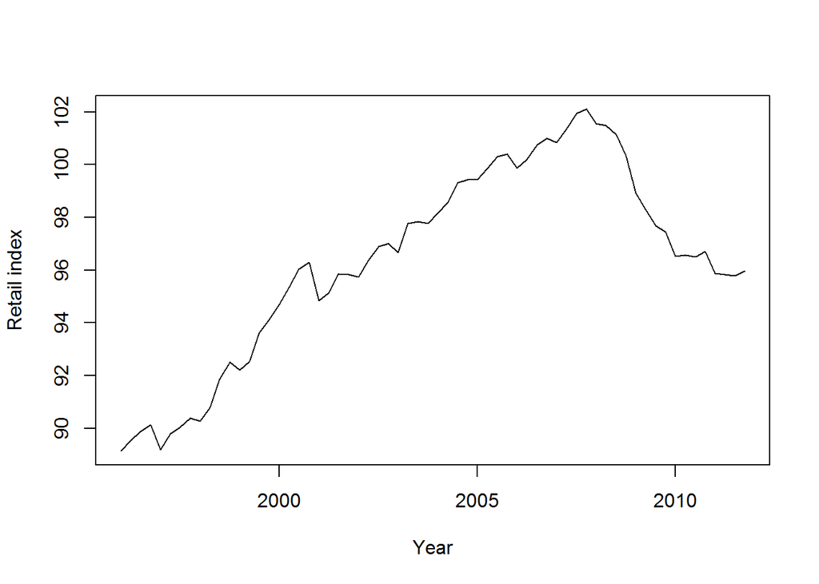

```r
plot(euretail, ylab="Retail index", xlab="Year")
```

The data are clearly non-stationary, with some seasonality, so we will first take a seasonal difference.

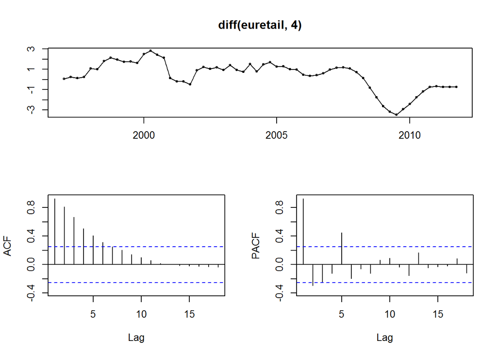

```r
tsdisplay(diff(euretail,4))
```

These also appear to be non-stationary, and so we take an additional first difference

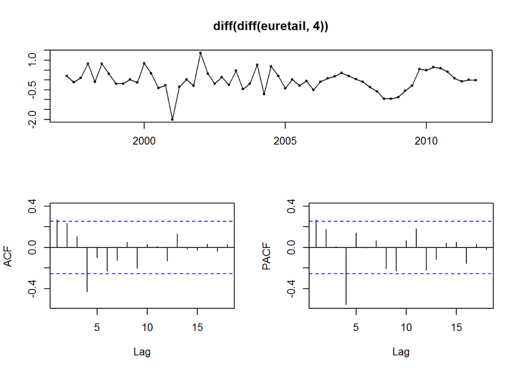

```r
tsdisplay(diff(diff(euretail,4)))
```

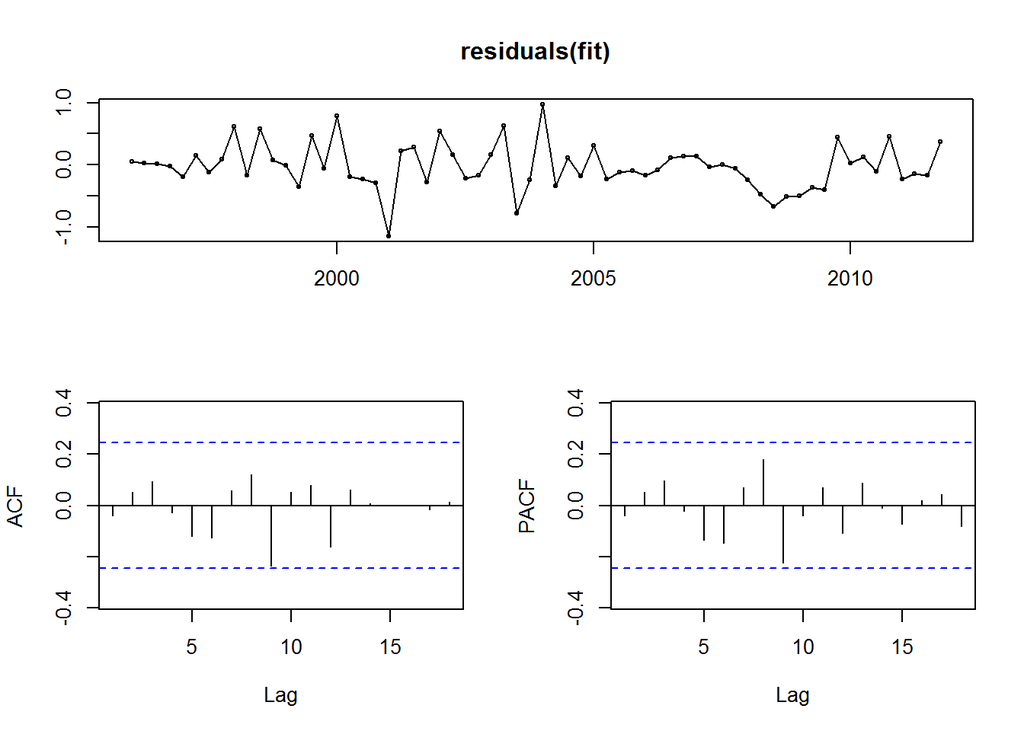

```r
fit <- Arima(euretail, order=c(1,1,1), seasonal=c(1,1,1))
tsdisplay(residuals(fit))
```

All the spikes are now within the significance limits, and so the residuals appear to be white noise.

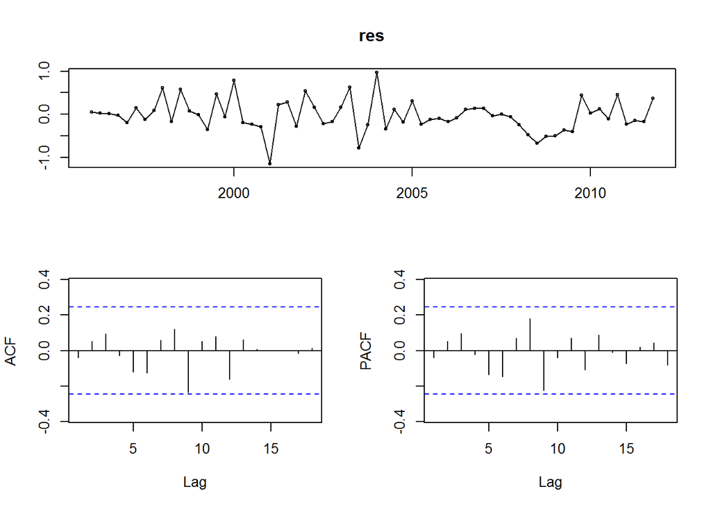

```r
fit.season <- Arima(euretail, order=c(1,1,1), seasonal=c(1,1,1))
res <- residuals(fit.season)
tsdisplay(res)
```

```r
Box.test(res, lag=16, fitdf=4, type="Ljung")
```

```
##
##  Box-Ljung test
##
## data:  res
## X-squared = 11.889, df = 12, p-value = 0.4547
```

prediction

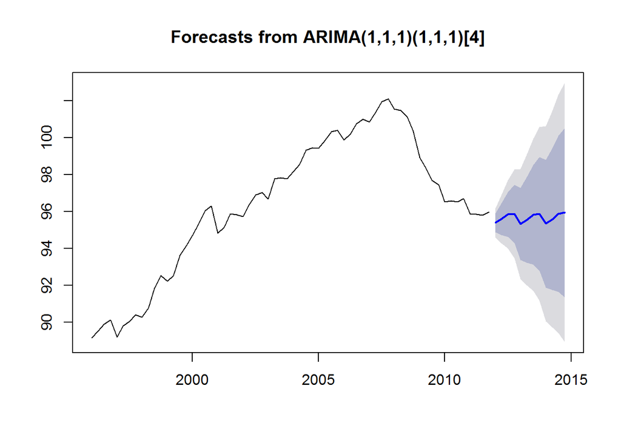

```r
plot(forecast(fit.season, h=12))
```

We could have used auto.arima() to do most of this work for us.

```r
auto.arima(euretail)
```

```
## Series: euretail
## ARIMA(1,1,2)(0,1,1)[4]
##
## Coefficients:
##          ar1      ma1     ma2     sma1
##       0.7345  -0.4655  0.2162  -0.8413
## s.e.  0.2239   0.1995  0.2096   0.1869
##
## sigma^2 estimated as 0.1592:  log likelihood=-29.69
## AIC=69.37   AICc=70.51   BIC=79.76
```

auto.arima() takes some short-cuts in order to speed up the computation and will not always give the best model. You can turn the short-cuts off and then it will sometimes return a different model.

```r
auto.arima(euretail, stepwise=FALSE, approximation=FALSE)
```

```
## Series: euretail
## ARIMA(0,1,3)(0,1,1)[4]
##
## Coefficients:
##          ma1     ma2     ma3     sma1
##       0.2625  0.3697  0.4194  -0.6615
## s.e.  0.1239  0.1260  0.1296   0.1555
##
## sigma^2 estimated as 0.1564:  log likelihood=-28.7
## AIC=67.4   AICc=68.53   BIC=77.78
```

remenber the 1-7 steps? The automated algorithm only takes care of steps 3–5. So even if you use it, you will still need to take care of the other steps yourself.

## how does auto.arima work

combines unit root tests, minimization of the AICc and MLE to obtain an ARIMA model. ARIMA(p,d,q) - The number of differences d is determined using repeated KPSS(unit root test) tests. - The values of p and q are then chosen by minimizing the AICc after differencing the data dd times, stepwised. - If d=0 then the constant c is included, or is set to 0.

## back to our own data

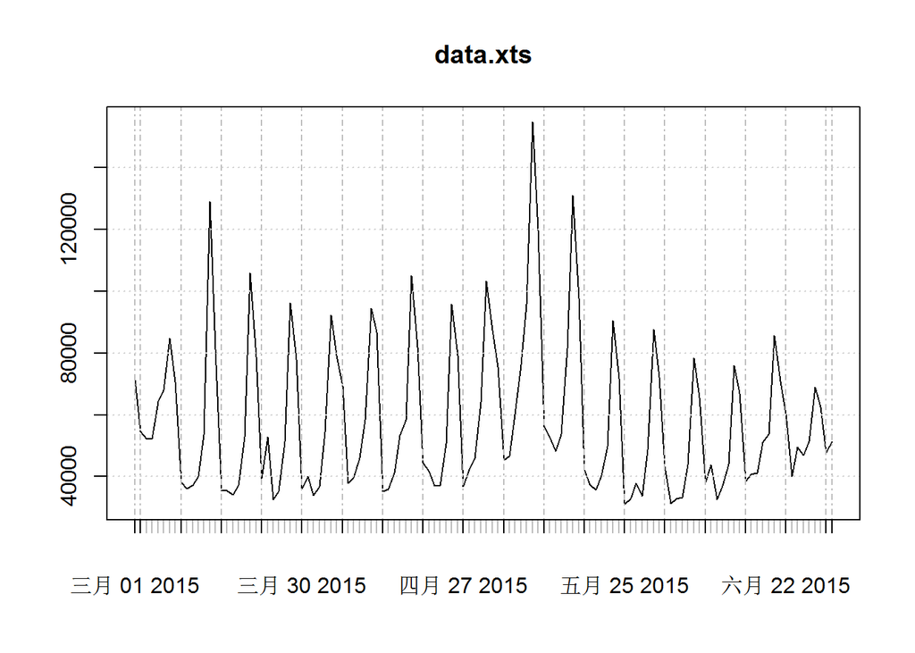

```r
plot(data.xts)
```

```r
train <- ts( log(data$new[1:100]), frequency =7 )

fit <- auto.arima( train, seasonal = T, stepwise=FALSE, approximation=FALSE)
fit
```

```
## Series: train
## ARIMA(1,0,0)(2,0,0)[7] with non-zero mean
##
## Coefficients:
##          ar1    sar1    sar2  intercept
##       0.5599  0.5221  0.3247    10.8787
## s.e.  0.0843  0.0975  0.1031     0.1971
##
## sigma^2 estimated as 0.03852:  log likelihood=18.82
## AIC=-27.63   AICc=-26.99   BIC=-14.6
```

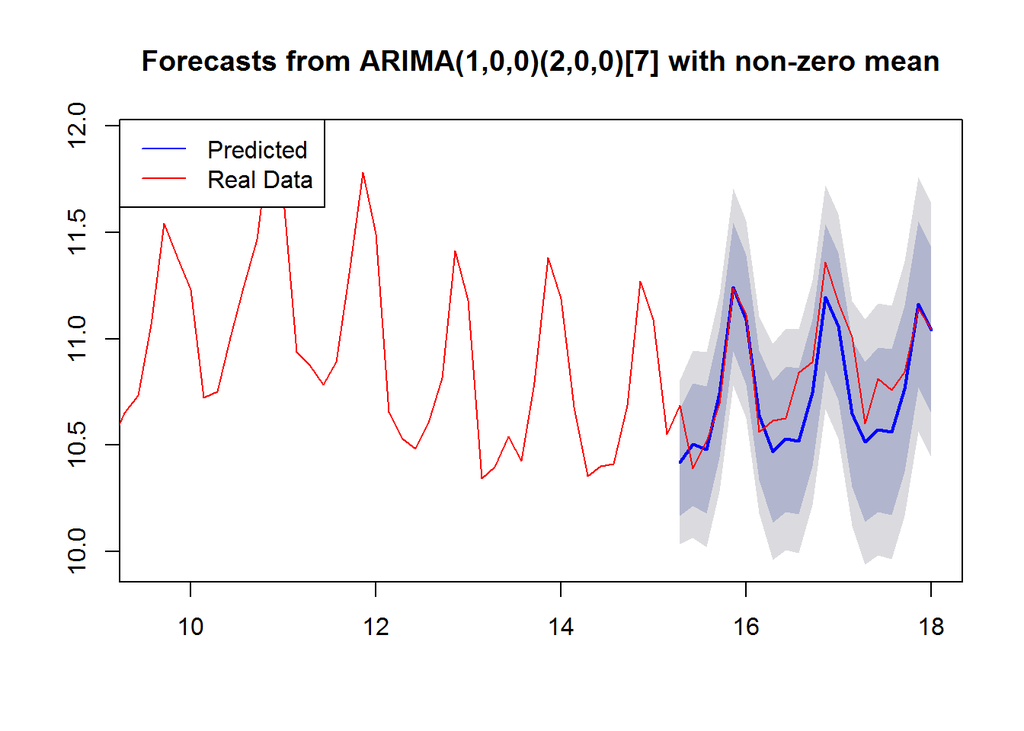

```r
data.forecast <- forecast(fit, h=20)

plot( data.forecast, include =40 )
lines( ts( log( data$new[1:120]), frequency=7 ), col ='red')
legend(x = "topleft", legend = c("Predicted", "Real Data"),
       col = c("blue", "red"), lty = c(1, 1))
```

```r
accuracy( data.forecast, data$new[101:120] )
```

```
##                         ME         RMSE          MAE        MPE      MAPE
## Training set -8.053632e-03 1.922932e-01 1.404425e-01 -0.1085542  1.289064
## Test set      5.311885e+04 5.499932e+04 5.311885e+04 99.9784776 99.978478
##                      MASE        ACF1
## Training set 4.665348e-01 0.004771361
## Test set     1.764551e+05          NA
```

# 不知道有什么卵用，暂时堆在这里

```r
#
# library(xts)
# data <- xts( raw[,-1], order.by= raw[,1], frequency =  7)
# plot(data);rm(raw)
#
# index = which( .indexwday( train )  %in% c(0,6) )
#
# wkend =   mean( train[ index ] )
# wkday =   mean( train[ -index ] )
#
#
# train = window(data, end = '2015-06-30')
# # test = window( data, start = '2015-07-01', end = '2015-07-15')
# test = window( data, start = '2015-07-01' )
#
# # acf, pacf
# plot( train )
#
# acf(train )
# pacf( train )
# Box.test(train)
#
# l =  diff(train)[-1]
# acf(l)
# pacf(l)
#
# # arima
# library( forecast)
# fit = auto.arima(train )
#
# fit = arima( train, order = c(2,0,0) )
#
# fit = arima( train ,order = c(2,0,0), seasonal=list(order=c(0,1,1),period=7) )
#
# # Exponential smoothing state space model
# fit = ets(  ts(train, frequency = 7) )
#
#
# summary(fit)
# plot( forecast( fit, 15))
#
#
# # plot.nz(fit)
# fore = xts( forecast( fit, h = length(test) )$mean , order =index(test)  )
# foree = merge(  test, fore  )
# plot(as.zoo(foree), main = paste( fit$arma, collapse = "") ,
#      screens=1, col=c("blue","red"), lty = c("solid","dotted") )
# legend( "topleft", legend = c("real","fore"), col = c("blue","red"), lty = c("solid","dotted"))
#
# round( (colSums( foree[,1])- colSums( foree[,2])) /colSums( foree[,1]), 2)
```

## filter

```r
#
# effect.week = aggregate( data$new, by = list(weekday= weekdays(data$date)), mean)
# effect.week$x = effect.week$x/ min(effect.week$x)
# effect.week
#
#
# data1 <- data
# for( i in 1:nrow(effect.week) ) {
#   ind <- effect.week$weekday[i]
#   data1$nv[weekdays(data$date) == ind] <-
#     data$new[ weekdays(data$date) == ind ]/effect.week$x[i]
# }
#
# data1
# aindexb <- function(x,y) { value = ifelse( weekdays(x$date)== y$weekday,
#                                    x$new/y$)}
#
# data.ts.week
```

```r
knitr::kable(mtcars)
```

[output not shown]

https://www.otexts.org/fpp/6/3